# SMS spam text classification

2019/12/1

[Text-Classification](https://cfss.uchicago.edu/notes/supervised-text-classification/)

# 1 首先…

使用`read_csv`读取数据后无需使用`tibble`函数转化。`read_csv`能够直接得到`tibble`对象。不然会报错。

R在构建文档-词语矩阵的有许多实现方式。下面使用了`tm::DocumentTermMatrix`函数实现。在此之前，我尝试了`quanteda::dfm_weight`函数，但是在我的本地R软件中总是报错（在Kaggle上的R Notebook能够运行）。另一个可能的路径是使用`tidytext::unnest_tokens`等函数进行去除停止词、去除数字和标点符号、提取词干等一系列操作；再通过`tidytext::cast_dtm`转化成`DocumentTermMatrix`对象。但这么做会导致因变量和特征矩阵行数不一致的问题。由于我无法解决它，我采用了下面的方案。当然使用Python是非常好的选择，我在[这里](https://www.kaggle.com/rikdifos/sms-text-classification)给出了基于Python的做法。相比R，Python的可视化能力略显不足。

我认为`tidytext`十分适合对文本信息进行探索和可视化，而`tm`则适合构建矩阵进行建模。如果将二者混用则可能导致问题。

# 2 上代码

```r
library(magrittr)
library(quanteda)
library(tidytext)
library(ggplot2)
library(dplyr)
library(tm)
library(readr)
library(stringr)
```

```r
sms <- read_csv("E:/MaLearning/SPAM text message 20170820 - Data.csv")
```

原数据共两列，其中一列记录了是否为垃圾短信的标签。另一列是短信文本内容。其中，非垃圾邮件的比例约为0.87，垃圾邮件的比例为0.13。

```r
sms %>% count(Category)
```

```
# A tibble: 2 x 2
  Category     n
  <chr>    <int>
1 ham       4825
2 spam       747
```

```r
#sms %$% prop.table(table(Category))[1]
```

数据概览如下：

```r
smswd <- sms %>%
  rename(message = Message,tag=Category) %>%
  mutate(ID = row_number())
head(smswd)
```

```
# A tibble: 6 x 3
  tag   message                                                          ID
  <chr> <chr>                                                         <int>
1 ham   Go until jurong point, crazy.. Available only in bugis n gre~     1
2 ham   Ok lar... Joking wif u oni...                                     2
3 spam  Free entry in 2 a wkly comp to win FA Cup final tkts 21st Ma~     3
4 ham   U dun say so early hor... U c already then say...                 4
5 ham   Nah I don't think he goes to usf, he lives around here though     5
6 spam  FreeMsg Hey there darling it's been 3 week's now and no word~     6
```

```r
Y <- as.factor(smswd$tag)
```

```r
smsvis <- smswd %>%
  unnest_tokens(word,message) %>%
  filter(!str_detect(word, "^[0-9]*$")) %>%
  anti_join(stop_words) %>%
  mutate(word = SnowballC::wordStem(word))
head(smsvis)
```

```
# A tibble: 6 x 3
  tag      ID word
  <chr> <int> <chr>
1 ham       1 jurong
2 ham       1 crazi
3 ham       1 bugi
4 ham       1 world
5 ham       1 la
6 ham       1 buffet
```

[figure not shown]

```r
library(reshape2)
library(wordcloud)
smsvis %>%
  count(word, tag, sort = T) %>%
  acast(word ~ tag, value.var = "n", fill = 0) %>%
  comparison.cloud(colors = c("blue", "red"),max.words = 50)
```

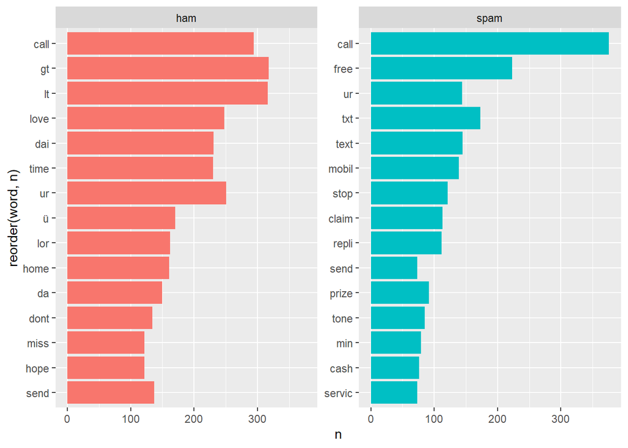

```r
smsvis %>%
  count(tag, word) %>%
  group_by(tag) %>%
  top_n(15) %>%
  ggplot() +
  geom_col(aes(reorder(word, n),
               n, fill = tag),
           show.legend = F) +
  facet_wrap(~tag, scales = "free_y") +
  coord_flip()
```

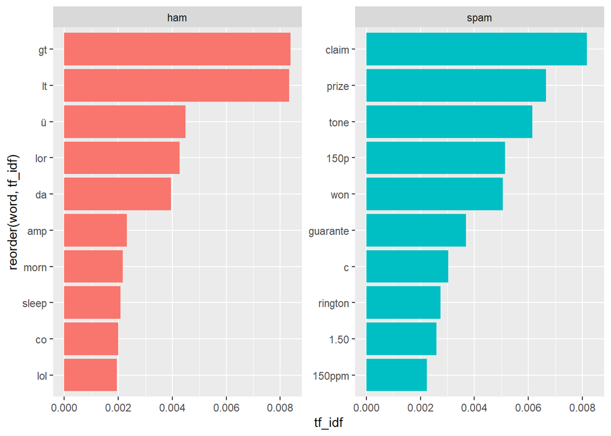

```r
smsvis %>%
  count(tag, word) %>%
  bind_tf_idf(word,tag,n) %>%
  group_by(tag) %>%
  top_n(10) %>%
ggplot() +
  geom_col(aes(reorder(word,tf_idf),
             tf_idf, fill = tag),
           show.legend = F) +
  facet_wrap(~tag, scales = "free_y") +
  coord_flip()
```

```r
ms_corpus <- VCorpus(VectorSource(smswd$message))

sms_dtm <- DocumentTermMatrix(ms_corpus, control =
                                 list(tolower = T,
                                      removeNumbers = T,
                                      stopwords = T,
                                      removePunctuation = T,
                                      stemming = T))

dim(sms_dtm) #5572
```

```
[1] 5572 7015
```

```r
sms_dtm1 <- removeSparseTerms(sms_dtm, sparse = .98)
smsmat <- as.matrix(sms_dtm1)
#head(smsmat)
dim(smsmat)
```

```
[1] 5572   51
```

原本的文档-词语频率矩阵有7015个特征，维度过高且过于稀疏。经过`removeSparseTerms`函数处理后保留了51个特征。

# 3 算法

朴素贝叶斯常常被用作文本分类的基线模型。因为文本数据满足每个单词相互独立。而且，一个单词的位置不依赖于另一个单词。也就是说，用于建模的文档-词语频率矩阵(DTM)各列独立，这满足了朴素贝叶斯的独立性假设。此外，为了提高准确率，我还进一步使用了支持向量机方法。

```r
library(caret)
library(e1071)
svmc <- svm(smsmat, Y)
print(svmc)
```

```
Call:
svm.default(x = smsmat, y = Y)


Parameters:
   SVM-Type:  C-classification
 SVM-Kernel:  radial
       cost:  1
      gamma:  0.01960784

Number of Support Vectors:  1380
```

```r
summary(svmc)
```

```
Call:
svm.default(x = smsmat, y = Y)


Parameters:
   SVM-Type:  C-classification
 SVM-Kernel:  radial
       cost:  1
      gamma:  0.01960784

Number of Support Vectors:  1380

 ( 851 529 )


Number of Classes:  2

Levels:
 ham spam
```

```r
pred <- predict(svmc,smsmat)
#confusionMatrix(pred,Y,positive ='spam',mode="prec_recall")
conMatrix <- confusionMatrix(pred,Y,positive ='spam',mode="prec_recall")
conMatrix[["table"]]
```

```
          Reference
Prediction  ham spam
      ham  4758  125
      spam   67  622
```

```r
nb <- naiveBayes(smsmat, Y)
#print(nb)
#summary(nb)
pred1 <- predict(nb,smsmat)

conMatrix1 <- confusionMatrix(pred1,Y,positive ='spam',mode="prec_recall")
#混淆矩阵
conMatrix1[["table"]]
```

```
          Reference
Prediction  ham spam
      ham  1985   48
      spam 2840  699
```

```r
prop.table(conMatrix1[["table"]],1)
```

```
          Reference
Prediction        ham       spam
      ham  0.97638957 0.02361043
      spam 0.80248658 0.19751342
```

支持向量机算法的准确率为0.97，平衡准确率为0.91。

朴素贝叶斯算法的准确率为0.48，平衡准确率为0.67。

编写一个对混淆矩阵进行可视化的函数：

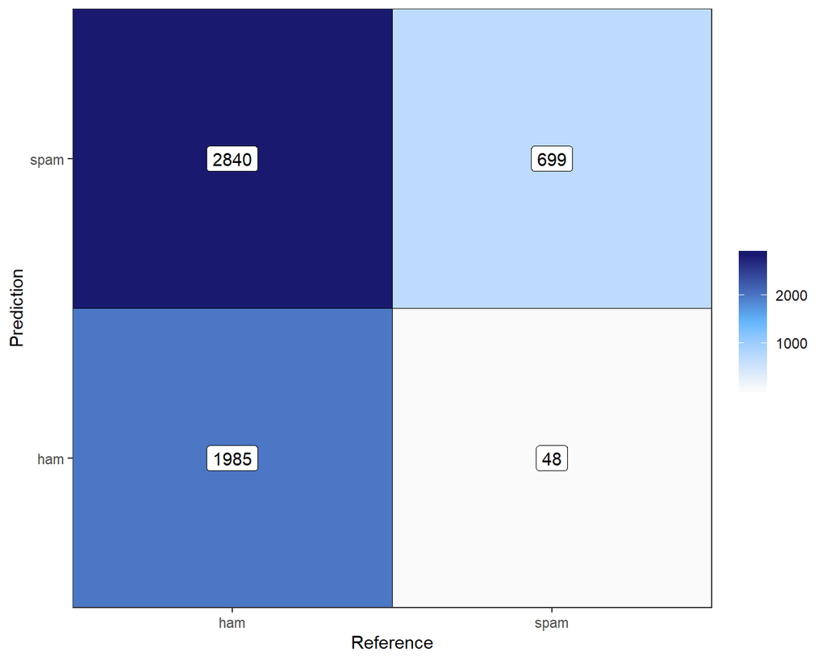

```r
plot_table <- function(x,xlab='Predicted label',
                       ylab='True label',
                       normalize = F){
  if(normalize){
    x <- round(prop.table(x,1), 2)
    mar <- as.data.frame(x)
  }
  else{
    mar <- as.data.frame(x)
  }
  ggplot2::ggplot(mar,aes(mar[,2],mar[,1])) +
    geom_tile(aes(fill=Freq),color='black') +
    scale_fill_gradientn(colours = c('gray98',
                                     'steelblue1',
                                     'midnightblue'))+
    geom_label(aes(label = Freq)) +
     labs(fill='',x=xlab,y=ylab) +
     ylim(rev(levels(mar[,2])))+
     scale_y_discrete(expand=c(0,0))+
     scale_x_discrete(expand=c(0,0))
}

plot_table(conMatrix1[["table"]],'Reference','Prediction')+
  theme_bw()
```

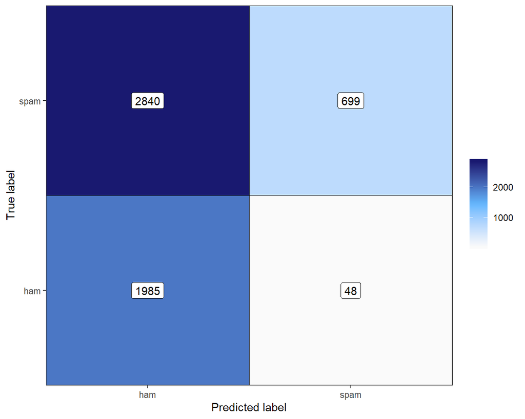

```r
plot_table(conMatrix1[["table"]])+
  theme_bw()
```

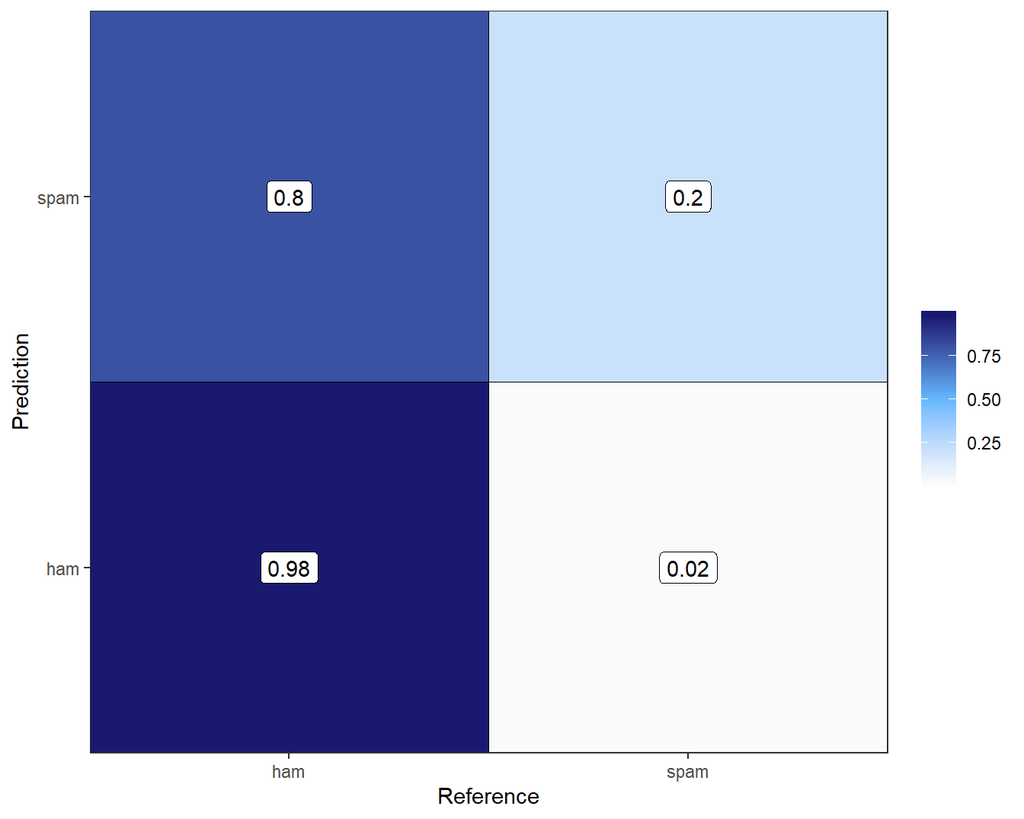

```r
plot_table(conMatrix1[["table"]],'Reference','Prediction',normalize=T)+
  theme_bw()
```

抛开准确率问题不谈，这里有另一个问题，为了避免不必要的损失，大部分人更希望过滤系统尽可能不要把有用的信息删掉。也就是说：

> 宁可放过一千也不要错杀一个。

所以，对于这个任务来说，算法的精确率越高越好，召回率(或者说查全率)越低越好。根据混淆矩阵，SVM的召回率为0.83，朴素贝叶斯的召回率为0.94。SVM的精确率为0.9，朴素贝叶斯的精确率为0.2。从混淆矩阵中我们也能看出，朴素贝叶斯算法将更多普通短信归类于垃圾短信了。因此SVM显然是更佳的模型。

# 4 应用

下面我们用自己输入的短信文本放入朴素贝叶斯模型进行评价。

```r
new <- 'please go home at 4 o clock bro'

new2 <- 'We are trying to contact you.Please call our customer service representative on FREEPHONE.Claim code S89. Valid 12hrs only'

test_result <- function(model,string){
  ms_corpus <- VCorpus(VectorSource(string))
test_dtm <- DocumentTermMatrix(ms_corpus, control =
                                 list(tolower = T,
                                      removeNumbers = T,
                                      stopwords = T,
                                      removePunctuation = T,
                                      stemming = T))
test_dtmx <- as.matrix(test_dtm)
result <- predict(model,test_dtmx)
return(result)
}

test_result(nb,new)
```

```
[1] ham
Levels: ham spam
```

```r
test_result(nb,new2)
```

```
[1] spam
Levels: ham spam
```